# Fubon E-bank Captcha Solver

## This notebook demonstrates a step-by-step implementation on solving the Captcha on Fubon E-bank website

- Captcha Image Scrapped
- Create Training Set
- Predicting
- Adjustment
- Result

### Captcha Image Scrapped

To download the captcha image from the website, we make use of Selenium to extract the captcha image from the website. The following lines of codes will navigate to Fubon E-bank Website and extract the captcha image and then save it in the folder.

```python
import pandas as pd
import numpy as np
import openpyxl
from selenium import webdriver
import chromedriver_autoinstaller
import time
import urllib.request
import base64
import random
import cv2
import matplotlib.pyplot as plt
import glob
from collections import Counter
```

```python
path = chromedriver_autoinstaller.install(".")
browser = webdriver.Chrome(executable_path = path)
browser.get("https://ebank.taipeifubon.com.tw/B2C/common/Index.faces")
browser.switch_to.frame("frame1")
browser.find_element("xpath", "//*[@id='header_form:header_login']").click()
browser.switch_to.frame("txnFrame")
img_path = browser.find_element("xpath", "/html/body/div[3]/div/div/div[2]/div[1]/table/tbody/tr[4]/td[2]/span/img")
img_captcha_base64 = browser.execute_async_script("""
        var ele = arguments[0], callback = arguments[1];
        ele.addEventListener('load', function fn(){
        ele.removeEventListener('load', fn, false);
        var cnv = document.createElement('canvas');
        cnv.width = this.width; cnv.height = this.height;
        cnv.getContext('2d').drawImage(this, 0, 0);
        callback(cnv.toDataURL('image/jpeg').substring(22));
        }, false);
        ele.dispatchEvent(new Event('load'));
        """, img_path)
with open(f"image.jpg", 'wb') as f:
        f.write(base64.b64decode(img_captcha_base64))
```

### Create Training Set

After checking the captcha image, we could find out that the numbers do not overlap with each other. Therefore, my strategy is to separate each number from the training set to serve as the training image. To do this, I performed some image processing techniques and extrated every number from the captcha image.

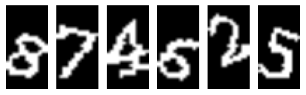

```python
test = cv2.imread(r"image.jpg")
test = cv2.cvtColor(test, cv2.COLOR_BGR2GRAY) # convert image to grayscale image
ret, test_bi = cv2.threshold(test, 180, 255, cv2.THRESH_BINARY_INV) # thresholding, convert image to binary image
contour, hierarchy = cv2.findContours(test_bi, mode = cv2.RETR_EXTERNAL, method = cv2.CHAIN_APPROX_NONE) # find objects in the image
boundingbox = [cv2.boundingRect(cnt) for cnt in contour] # create bounding rectangle according to the objects found
start = []; end = []
for bbox in boundingbox:
    [x, y, w, h] = bbox
    start.append(x)
    end.append(x + w)
start = sorted(start)
end = sorted(end)
image_train = []
for i in range(len(start)):
    image_train.append(cv2.resize(test_bi[:, start[i]:end[i]], (30, 60), interpolation = cv2.INTER_LINEAR))
fig, ax = plt.subplots(nrows = 1, ncols = 6)
for i in range(len(image_train)):
    eval(f"ax[{i}].imshow(image_train[{i}], cmap = 'gray')")
    eval(f"ax[{i}].axis('off')")
```

As a result, we could get 6 training image for one captcha image like above.

### Predicting

Here, we use KNN to solve the captcha image. I have 196 testing image and 465 segmented training image in total. To decide how many neighbor to use in KNN, I would try on the first 50 image and loop over $k = 1$ to $k = 20$ and check the accuracy I could get under different value of $k$.

```python
training_path = glob.glob("training set\\*"); testing_path = glob.glob("testing set\\*")
training_path = sorted(training_path, key = lambda x: int(x.split("\\")[-1].split(".")[0].split("_")[-1]))
testing_path = sorted(testing_path, key = lambda x: int(x.split("\\")[-1].split(".")[0].split("image")[-1]))
training_set = []; testing_set = []
for i in training_path:
    img_train = cv2.imread(i)
    img_train = cv2.cvtColor(img_train, cv2.COLOR_BGR2GRAY)
    thresh, img_train = cv2.threshold(img_train, 50, 1, cv2.THRESH_BINARY)
    img_train = img_train.astype(np.int16)
    training_set.append(img_train)
training_set = np.array(training_set)
training_label = pd.read_csv("train label.csv")
training_label = list(training_label.iloc[:, 1])
for i in testing_path:
    testing_set.append(cv2.imread(i))
testing_label = pd.read_excel("test label.xlsx", dtype = "object")
testing_label = list(testing_label.iloc[:, 1])




def knn(training_set, training_label, testing, k):
    test = cv2.cvtColor(testing, cv2.COLOR_BGR2GRAY)
    ret, test_bi = cv2.threshold(test, 180, 255, cv2.THRESH_BINARY_INV)
    contour, hierarchy = cv2.findContours(test_bi, mode = cv2.RETR_EXTERNAL, method = cv2.CHAIN_APPROX_NONE)
    boundingbox = [cv2.boundingRect(cnt) for cnt in contour]
    start = []; end = []; test_seg = []
    for bbox in boundingbox:
        [x, y, w, h] = bbox
        start.append(x)
        end.append(x + w)
    start = sorted(start)
    end = sorted(end)
    try:
        for j in range(6):
            tmp = test_bi[:, start[j]:end[j]]
            tmp = cv2.resize(tmp, (30, 60), interpolation = cv2.INTER_LINEAR)
            tmp = tmp.astype(np.int16)
            test_seg.append(tmp)

        result = []
        for j in test_seg:
            subtract = training_set - j
            r = subtract.shape[0]; c = subtract.shape[1] * subtract.shape[2]
            subtract = subtract.reshape(r, c)
            dist = np.linalg.norm(subtract, axis = 1, ord = 1)
            closest = sorted(range(len(dist)), key = lambda x: dist[x])[:k]
            predict = []
            for l in closest:
                predict.append(training_label[l])
            result.append(str(Counter(predict).most_common(1)[0][0]))
        result = "".join(result)
        result = str(result)
        return result
    except IndexError:
        return None


result = []
n = 50
for i in range(1, 21, 2):
    count = 0
    for j in range(n):
        predict = knn(training_set, training_label, testing_set[j], i)
        if predict == str(testing_label[j]):
            count += 1
    result.append(np.round(count / 50, 2))
```

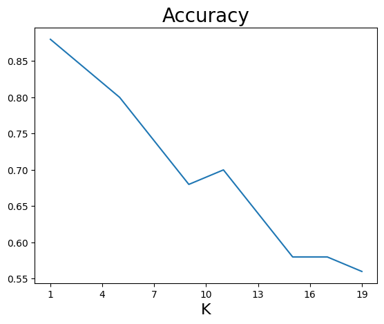

```python
x = np.arange(1, 21, 2)
xticklabel = np.arange(1, 21, 3)
fig, ax = plt.subplots()
ax.plot(x, result)
ax.set_title("Accuracy", size = 20)
ax.set_xlabel("K", size = 16)
ax.set_xticks(xticklabel)
ax.set_xticklabels([str(i) for i in xticklabel])
plt.show()
```

Here, we could find out that with increase K, we would obtain lower accuracy. So I end up to choose $k = 1$. That is, for every segmentated number in testing set, it would be labeled as the closest image in the training set. Next, I choose $k = 1$ to see how many image we are able to successfully solve.

```python
result = []
n = len(testing_set)
count = 0
for j in range(n):
    predict = knn(training_set, training_label, testing_set[j], 1)
    if predict == str(testing_label[j]):
        count += 1
print(count)
```

```
169
```

Congradulations !!! I successfully solve 169 captcha image from 196 captcha image. With some simple image processing techniques and algorithm, I could automatically the process of solving captcha image. However, to work on a better result, let's check why I fail to solve some of the captcha images.

### Adjustment

```python
fail = []
count = 0
for j in range(n):
    predict = knn(training_set, training_label, testing_set[j], 1)
    if predict != str(testing_label[j]):
        fail.append([j, testing_set[j], predict])
```

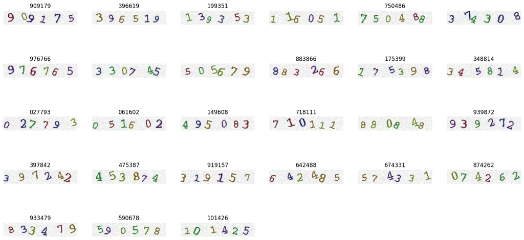

```python
fig = plt.figure(figsize = [20, 10])
for i in range(len(fail)):
    ax = fig.add_subplot(5, 6, i+1)
    ax.imshow(fail[i][1])
    ax.axis("off")
    ax.set_title(fail[i][2])
plt.show()
```

This is a plot of captcha image I fail to solve. The title of the image is the result predicted by 1-NN classifier. For those image that do not have title above means that there is a problem when doing image segmentation. We could see that if there are numbers that are slightly overlap, the method would raise an error. In addition, the number "5" seems to have the highest uncorrect rate. I would try to solve the first problem by making some adjustments regarding image segmentation.

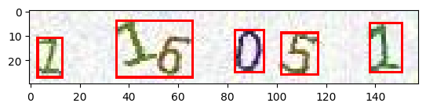

```python
img = testing_set[41].copy()
test = cv2.cvtColor(img, cv2.COLOR_BGR2GRAY)
ret, test = cv2.threshold(test, 180, 255, cv2.THRESH_BINARY_INV)
contour, hierarchy = cv2.findContours(test, mode = cv2.RETR_EXTERNAL, method = cv2.CHAIN_APPROX_NONE)
boundingbox = [cv2.boundingRect(cnt) for cnt in contour]

fig, ax = plt.subplots()

for bbox in boundingbox:
    [x, y, w, h] = bbox
    cv2.rectangle(img, (x, y), (x + w, y + h), (255, 0, 0), 1)
ax.imshow(img)
plt.show()
```

By showing one of the image which doesn't have title, we could see that as two numbers are too close to each other, they have been included in the same bounding box. To solve this problem, we first observe that although these two numbers are close to each other, they occupy almost half of the bounding box. Therefore, my solution is to cut the bounding box into half to create two new bounding boxes.

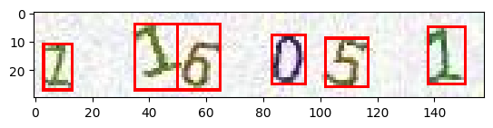

```python
img = testing_set[41].copy()
test = cv2.cvtColor(img, cv2.COLOR_BGR2GRAY)
ret, test_bi = cv2.threshold(test, 180, 255, cv2.THRESH_BINARY_INV)
contour, hierarchy = cv2.findContours(test_bi, mode = cv2.RETR_EXTERNAL, method = cv2.CHAIN_APPROX_NONE)
boundingbox = [cv2.boundingRect(cnt) for cnt in contour]

boundingbox = sorted(boundingbox, key = lambda x: int(x[2]))
maxwidthbox = boundingbox[-1]
del boundingbox[-1]
new_box1 = (maxwidthbox[0], maxwidthbox[1], int(maxwidthbox[2] / 2), maxwidthbox[3])
new_box2 = (maxwidthbox[0] + int(maxwidthbox[2] / 2), maxwidthbox[1], int(maxwidthbox[2] / 2), maxwidthbox[3])
boundingbox.append(new_box1)
boundingbox.append(new_box2)
fig, ax = plt.subplots()
for bbox in boundingbox:
    [x, y, w, h] = bbox
    cv2.rectangle(img, (x, y), (x + w, y + h), (255, 0, 0), 1)
ax.imshow(img)
plt.show()
```

Here, as we could see, cutting the bounding box into half allows us to separate two numbers. Although there are some redundant areas in the bounding box, I don't think it would affect the result of 1-NN classifier. Then I use the modified version of image segmentation to test on my testing set with 1-NN classifier.

```python
def knn(training_set, training_label, testing, k):
    test = cv2.cvtColor(testing, cv2.COLOR_BGR2GRAY)
    ret, test_bi = cv2.threshold(test, 180, 255, cv2.THRESH_BINARY_INV)
    contour, hierarchy = cv2.findContours(test_bi, mode = cv2.RETR_EXTERNAL, method = cv2.CHAIN_APPROX_NONE)
    boundingbox = [cv2.boundingRect(cnt) for cnt in contour]
    start = []; end = []; test_seg = []
    if len(boundingbox) == 5:
        boundingbox = sorted(boundingbox, key = lambda x: int(x[2]))
        maxwidthbox = boundingbox[-1]
        del boundingbox[-1]
        new_box1 = (maxwidthbox[0], maxwidthbox[1], int(maxwidthbox[2] / 2), maxwidthbox[3])
        new_box2 = (maxwidthbox[0] + int(maxwidthbox[2] / 2), maxwidthbox[1], int(maxwidthbox[2] / 2), maxwidthbox[3])
        boundingbox.append(new_box1)
        boundingbox.append(new_box2)

    for bbox in boundingbox:
        [x, y, w, h] = bbox
        start.append(x)
        end.append(x + w)

    start = sorted(start)
    end = sorted(end)

    for j in range(6):
        tmp = test_bi[:, start[j]:end[j]]
        tmp = cv2.resize(tmp, (30, 60), interpolation = cv2.INTER_LINEAR)
        tmp = tmp.astype(np.int16)
        test_seg.append(tmp)

    result = []
    for j in test_seg:
        subtract = training_set - j
        r = subtract.shape[0]; c = subtract.shape[1] * subtract.shape[2]
        subtract = subtract.reshape(r, c)
        dist = np.linalg.norm(subtract, axis = 1, ord = 1)
        closest = sorted(range(len(dist)), key = lambda x: dist[x])[:k]
        predict = []
        for l in closest:
            predict.append(training_label[l])
        result.append(str(Counter(predict).most_common(1)[0][0]))
    result = "".join(result)
    result = str(result)
    return result

result = []
n = len(testing_set)
count = 0
for j in range(n):
    predict = knn(training_set, training_label, testing_set[j], 1)
    if predict == str(testing_label[j]):
        count += 1
print(count)
```

```
171
```

### Result

Great !! This modification helps me solve two more captcha images. In the end, I try my classification method on 1130 captcha images download from Fubon E-bank website. I manually check whether the predicted result is correct. The result below shows that this method solves 960 out of 1130 captcha images, which reaches a 85% accuracy !!

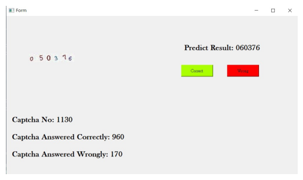

```python
img = cv2.imread("predict result.jpg")
img = cv2.cvtColor(img, cv2.COLOR_BGR2RGB)
fig, ax = plt.subplots()
ax.imshow(img)
ax.set_axis_off()
plt.show()
```